# Post-College Salaries Exploration in R

# 1 Setup and overview

There are 3 different data sets with post-college salary information:

- salaries by degree
- salaries by college and type
- salaries by college and region

Each of the data sets has the following features in common:

- starting median salary
- mid-career salaries for 10th, 25th, 50th, 75th, and 90th percentiles

```r
# load packages and data
library(tidyverse)
csv_files <- list.files(pattern = ".csv")

# if not worried about column types
#dfs <- map(csv_files, read_csv)
#names(dfs) <- c("deg", "col", "reg")

df_deg <- read_csv(csv_files[1],
                   col_names = c("major", "start_med_slry", "mid_car_slry",
                                 "percent_chng", "mid_car_10th", "mid_car_25th",
                                 "mid_car_75th", "mid_car_90th"),  # short names w/o whitespace
                   col_types = "cnndnnnn",  # specify column types to coerce '$' to numeric
                   skip = 1)  # names specified, skip header

df_col <- read_csv(csv_files[2],
                   col_names = c("school_name", "school_type", "start_med_slry",
                                 "mid_car_slry", "mid_car_10th", "mid_car_25th",
                                 "mid_car_75th", "mid_car_90th"),
                   col_types = "ccnnnnnn", skip = 1)

df_reg <- read_csv(csv_files[3],
                   col_names = c("school_name", "region", "start_med_slry",
                                 "mid_car_slry", "mid_car_10th", "mid_car_25th",
                                 "mid_car_75th", "mid_car_90th"),
                   col_types = "ccnnnnnn", skip = 1)
```

Here’s a brief look at the salaries by degree data set.

```r
glimpse(df_deg)
```

```
## Observations: 50
## Variables: 8
## $ major          <chr> "Accounting", "Aerospace Engineering", "Agricul...
## $ start_med_slry <dbl> 46000, 57700, 42600, 36800, 41600, 35800, 38800...
## $ mid_car_slry   <dbl> 77100, 101000, 71900, 61500, 76800, 64900, 6480...
## $ percent_chng   <dbl> 67.6, 75.0, 68.8, 67.1, 84.6, 81.3, 67.0, 67.7,...
## $ mid_car_10th   <dbl> 42200, 64300, 36300, 33800, 50600, 28800, 36900...
## $ mid_car_25th   <dbl> 56100, 82100, 52100, 45500, 62200, 42200, 47400...
## $ mid_car_75th   <dbl> 108000, 127000, 96300, 89300, 97000, 87400, 945...
## $ mid_car_90th   <dbl> 152000, 161000, 150000, 138000, 136000, 125000,...
```

There are comparitively few observations in this data set, and each observation corresponds to a college major. So the salary data contained within is across various colleges.

A glimpse of the salaries by college and type data set.

```r
glimpse(df_col)
```

```
## Observations: 269
## Variables: 8
## $ school_name    <chr> "Massachusetts Institute of Technology (MIT)", ...
## $ school_type    <chr> "Engineering", "Engineering", "Engineering", "E...
## $ start_med_slry <dbl> 72200, 75500, 71800, 62400, 62200, 61000, 61800...
## $ mid_car_slry   <dbl> 126000, 123000, 122000, 114000, 114000, 114000,...
## $ mid_car_10th   <dbl> 76800, NA, NA, 66800, NA, 80000, 63300, 71600, ...
## $ mid_car_25th   <dbl> 99200, 104000, 96000, 94300, 80200, 91200, 8010...
## $ mid_car_75th   <dbl> 168000, 161000, 180000, 143000, 142000, 137000,...
## $ mid_car_90th   <dbl> 220000, NA, NA, 190000, NA, 180000, 209000, 182...
```

Observations in this data set are by individual college, and each college has a type. I’m curious how the type designation was determined and if there are multiple types. It’s also clear there are some missing values.

Finally the salaries by college and region data set.

```r
glimpse(df_reg)
```

```
## Observations: 320
## Variables: 8
## $ school_name    <chr> "Stanford University", "California Institute of...
## $ region         <chr> "California", "California", "California", "Cali...
## $ start_med_slry <dbl> 70400, 75500, 71800, 59900, 51900, 57200, 52600...
## $ mid_car_slry   <dbl> 129000, 123000, 122000, 112000, 105000, 101000,...
## $ mid_car_10th   <dbl> 68400, NA, NA, 59500, NA, 55000, 51300, 51700, ...
## $ mid_car_25th   <dbl> 93100, 104000, 96000, 81000, 54800, 74700, 7250...
## $ mid_car_75th   <dbl> 184000, 161000, 180000, 149000, 157000, 133000,...
## $ mid_car_90th   <dbl> 257000, NA, NA, 201000, NA, 178000, 193000, 177...
```

Again observations appear to be individual colleges. But there are more observations in this data set than in the college-type one above. It looks like California is a region, and I wonder whether or not there are multiple instances of the same college with different regions. There are also some NAs as in the previous data set.

## 1.1 Duplicate colleges

Before I go into any analysis, I want to see whether or not there are multiple instances of the same college in either the college-type and college-region data sets.

```r
library(stringr)  # get in the spirit of tidyverse
# multiple college types
df_col %>%
  group_by(school_name) %>%
  mutate(count = n()) %>%  # no 'summarise' to keep 'school_type' feature
  filter(count > 1) %>%
  summarise(types = str_c(school_type, collapse = '-'))
```

| school_name | types |
| --- | --- |
| Arizona State University (ASU) | Party-State |
| Florida State University (FSU) | Party-State |
| Indiana University (IU), Bloomington | Party-State |
| Louisiana State University (LSU) | Party-State |
| Ohio University | Party-State |
| Pennsylvania State University (PSU) | Party-State |
| Randolph-Macon College | Party-Liberal Arts |
| State University of New York (SUNY) at Albany | Party-State |
| University of Alabama, Tuscaloosa | Party-State |
| University of California, Santa Barbara (UCSB) | Party-State |

[output cut: 10 more lines]

There are 20 colleges in the college by type data set with more than one college type. Let’s see if the same is true for the college by regions data set.

```r
# multiple college regions
df_reg %>%
  group_by(school_name) %>%
  mutate(count = n()) %>%
  filter(count > 1)
```

| school_name | region | start_med_slry | mid_car_slry | mid_car_10th | mid_car_25th | mid_car_75th | mid_car_90th | count |
| --- | --- | --- | --- | --- | --- | --- | --- | --- |

Fortunately there are no colleges listed with multiple regions. Because the college by region data set has the most observations, and is the most complete in terms of the number of unique colleges included, I’ll use that data set to explore any relationships between the salaries features.

## 1.2 Missing data

As seen, there are various missing values for different percentiles of mid-career salary. This appears to be most in the college by type and college by region data sets but I want to inspect this further.

Here is the missing data by feature for the college degree data set.

```r
# named vector to data frame
nmd_vec_to_df <- function(x, start_col) {
  nms <- names(x)
  dta <- unname(x)
  df <- data.frame()
  df <- rbind(df, dta)
  names(df) <- nms
  return(df[, start_col:length(colnames(df))])
}

colSums(is.na(df_deg)) %>% nmd_vec_to_df(2)
```

| start_med_slry | mid_car_slry | percent_chng | mid_car_10th | mid_car_25th | mid_car_75th | mid_car_90th |
| --- | --- | --- | --- | --- | --- | --- |
| 0 | 0 | 0 | 0 | 0 | 0 | 0 |

missing data by feature for college type data set

```r
colSums(is.na(df_col)) %>% nmd_vec_to_df(3)
```

| start_med_slry | mid_car_slry | mid_car_10th | mid_car_25th | mid_car_75th | mid_car_90th |
| --- | --- | --- | --- | --- | --- |
| 0 | 0 | 38 | 0 | 0 | 38 |

and the missing data by feature for college region data set

```r
colSums(is.na(df_reg)) %>% nmd_vec_to_df(3)
```

| start_med_slry | mid_car_slry | mid_car_10th | mid_car_25th | mid_car_75th | mid_car_90th |
| --- | --- | --- | --- | --- | --- |
| 0 | 0 | 47 | 0 | 0 | 47 |

So there is some missing data for the mid-career salaries of the 10th and 90th percentiles in both the college by type and college by region data sets. Luckily we have complete infomration for the 25th and 75th percentiles across all data sets so this should be able to give some idea for the range although not at the extremes of salaries.

# 2 Analysis

## 2.1 Distribution of starting and mid-career salaries

What are the distributions for starting median salary and mid-career median salary by college?

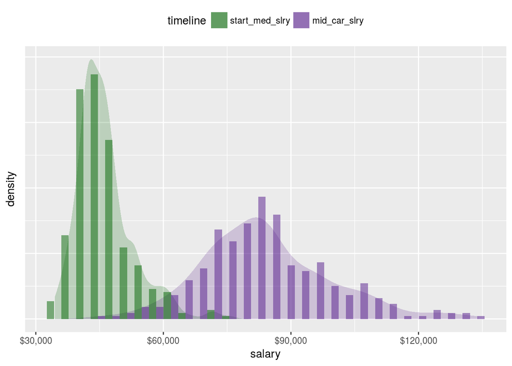

```r
library(forcats)  # easy factors

# select starting and mid-career salaries and reformat to long
df_start_vs_med <- df_reg %>%
  select(start_med_slry, mid_car_slry) %>%
  gather(timeline, salary) %>%
  mutate(timeline = as_factor(timeline, fct_rev))  # reverse levels, start salary first

# plot histogram with height as density and smoothed density
library(scales)
ggplot(df_start_vs_med, aes(salary, fill = timeline)) +
  geom_density(alpha = 0.2, color = NA) +
  geom_histogram(aes(y = ..density..), alpha = 0.5, position = 'dodge') +
  scale_fill_manual(values = c('darkgreen', 'purple4')) +
  scale_x_continuous(labels = dollar) +
  theme(legend.position = "top",
        axis.text.y = element_blank(), axis.ticks.y = element_blank())
```

The distribution for starting median salary is definitely concentrated at the lower range of salaries and is somewhat right-skewed. Graduates of most schools start out with a median of $45,100 although there is a maximum median starting salary of $75,500. As working time progresses to mid-career, the distribution of median (50th percentile) salaries becomes more dispersed and the median of these increases to $82,700

## 2.2 Any correlation between starting and mid-career salaries?

I would expect this to be true, but data due dilligence requires that we inspect this to see if there is any correlation, and if so, how strong it is.

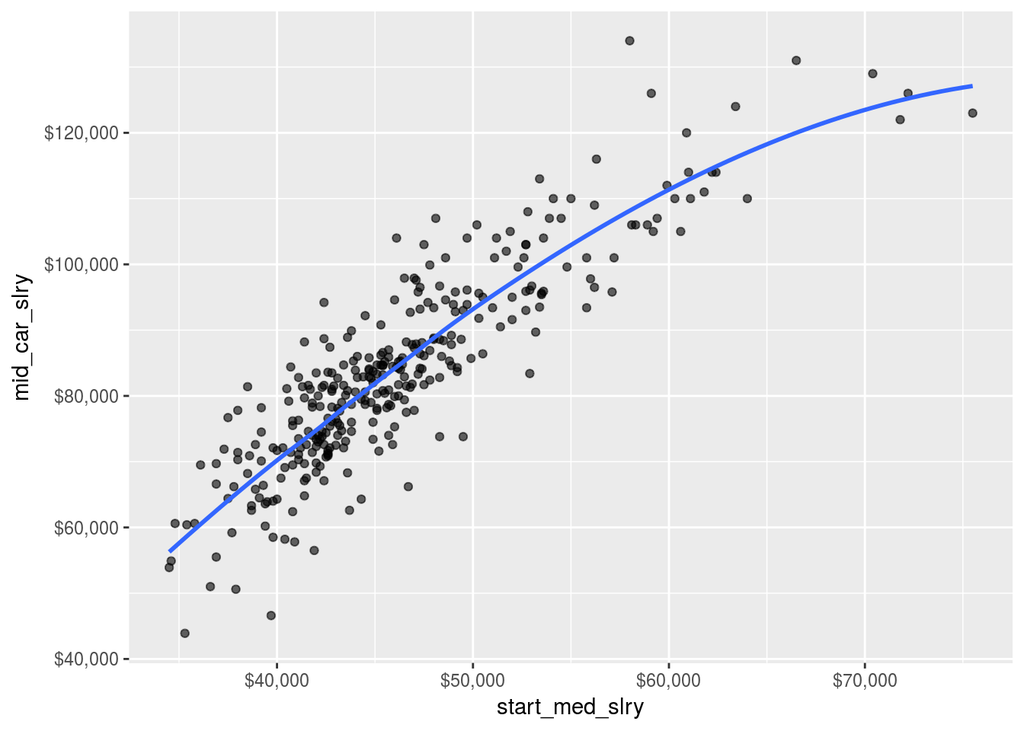

```r
ggplot(df_reg, aes(start_med_slry, mid_car_slry)) +
  geom_point(alpha = 0.6) +
  geom_smooth(se = F) +  # loess fit
  scale_x_continuous(labels = dollar) +
  scale_y_continuous(labels = dollar)
```

```r
paste('correlation coefficient',
      round(with(df_reg, cor(start_med_slry, mid_car_slry)), 4))
```

```
## [1] "correlation coefficient 0.8816"
```

There is a fairly strong correlation although the relationship is not simply linear. As starting median salary increases, the slope of a first order coefficient seems to decrease there doesn’t appear to be enough data at that end to make a conclusive statement.

# 3 Salaries by major

How do salaries differ by degree? Which majors show the highest starting salaries?

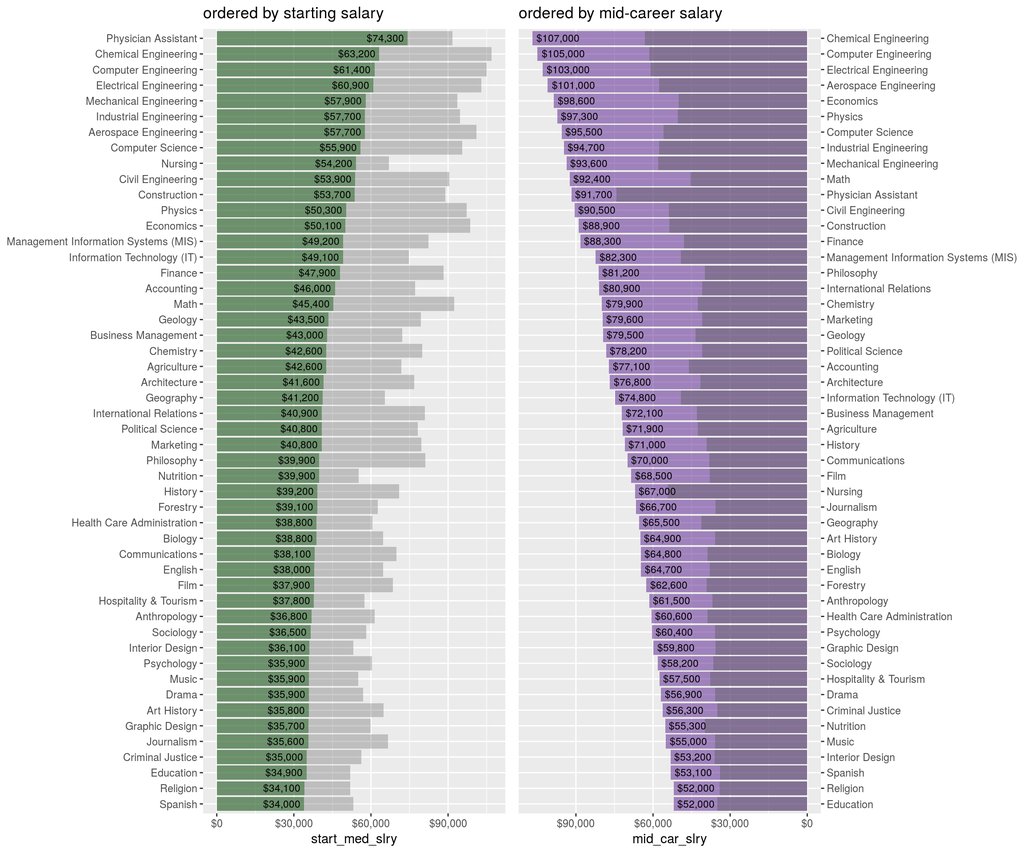

```r
p1 <- ggplot(df_deg, aes(x = reorder(major, start_med_slry), start_med_slry)) +
  geom_col(fill = "darkgreen", alpha = 0.5) +
  geom_col(aes(x = reorder(major, mid_car_slry), mid_car_slry), alpha = 0.3) +
  geom_text(aes(label = dollar(start_med_slry)), size = 3, hjust = 1.1) +
  scale_y_continuous(labels = dollar) +
  xlab(NULL) +
  coord_flip() +
  ggtitle("ordered by starting salary")

p2 <- ggplot(df_deg, aes(x = reorder(major, mid_car_slry), mid_car_slry)) +
  geom_col(alpha = 0.5, fill = 'purple4') +
  geom_col(aes(x = reorder(major, mid_car_slry), start_med_slry), alpha = 0.4) +
  geom_text(aes(label = dollar(mid_car_slry)), size = 3, hjust = -0.1) +
  scale_fill_manual(values = c('darkgreen', 'purple4')) +
  scale_y_reverse(labels = dollar) +
  scale_x_discrete(position = 'top') +
  xlab(NULL) +
  coord_flip() +
  ggtitle("ordered by mid-career salary")

library(gridExtra)
grid.arrange(p1, p2, nrow = 1)
```

Engineering, computer science, and 2 health occupational degrees have the highest median starting salaries. But what about long-term salary potential? Which degrees show the most growth in salary from starting to mid-career?

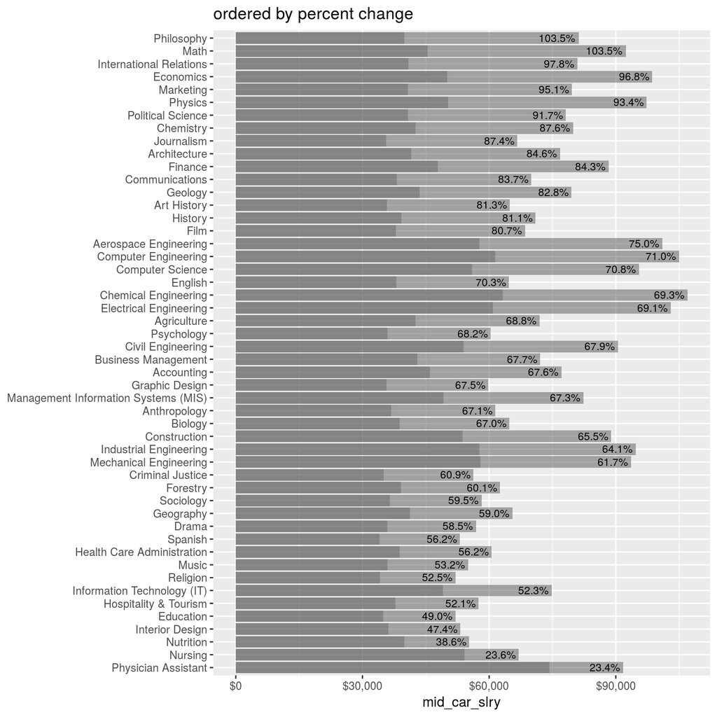

```r
ggplot(df_deg, aes(x = reorder(major, percent_chng), mid_car_slry)) +
  geom_col(alpha = 0.5) +
  geom_col(aes(x = reorder(major, percent_chng), start_med_slry), alpha = 0.4) +
  geom_text(aes(label = percent(percent_chng / 100)), size = 3, hjust = 1.1) +
  scale_y_continuous(labels = dollar) +
  xlab(NULL) +
  coord_flip() +
  ggtitle("ordered by percent change")
```

This plot is ordered by those degrees that show the most percent change in career salary. Although physician assistant has the highest starting salary, the median mid-career salary doesn’t show a lot of change. Majors like Philosophy and Math seem to grow the most by mid-career. We can see that many of the engineering degrees, although with not the most change, start high and still have a high mid-career salary.

To get an idea for the ranges of mid-career salary, here’s a plot of the different percentiles at mid-career. This plot is ordered by degrees with the highest 90th percentile of mid-career salary.

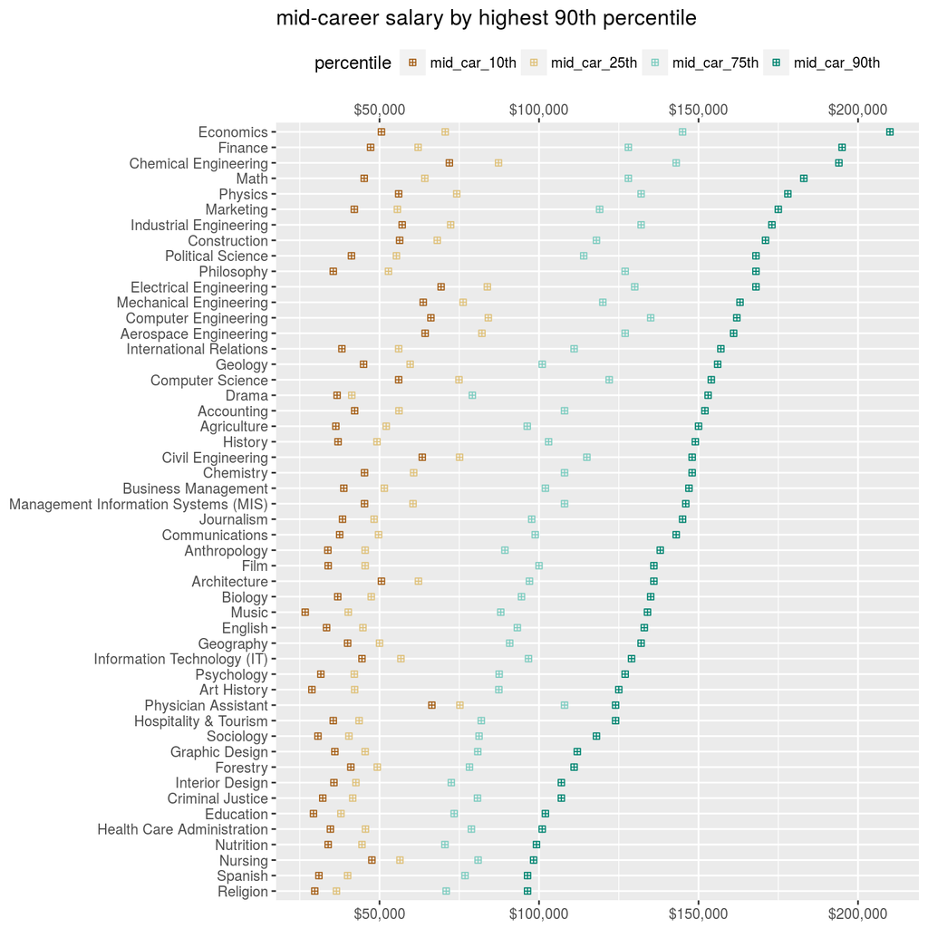

```r
# from wide to long format for mid-career percentiles
df_maj_mid_car <- df_deg %>%
  select(-start_med_slry, -percent_chng) %>%
  mutate(mid90th = mid_car_90th) %>%
  gather(percentile, salary, mid_car_10th:mid_car_90th)

ggplot(df_maj_mid_car, aes(x = reorder(major, mid90th),
                           y = salary,
                           color = percentile), color = 'gray') +
  geom_point(shape = 12) +
  scale_color_brewer(type = 'div') +
  scale_y_continuous(labels = dollar, sec.axis = dup_axis()) +
  labs(x = NULL, y = NULL) +
  coord_flip() +
  ggtitle("mid-career salary by highest 90th percentile") +
  theme(legend.position = "top")
```

Several majors such as economics, finance, and chemical engineering have a lot of salary potential. Others such as nutrition and nursing have a tight range of mid-career salary and those at the 90th percentile don’t appear to exceed the 100k salary mark. This is something to be aware of if you want to have a higher salary mid-career.

# 4 Salaries by college type

One of the data sets has salaries by college and college type. Here is a plot of the distribution over different college types.

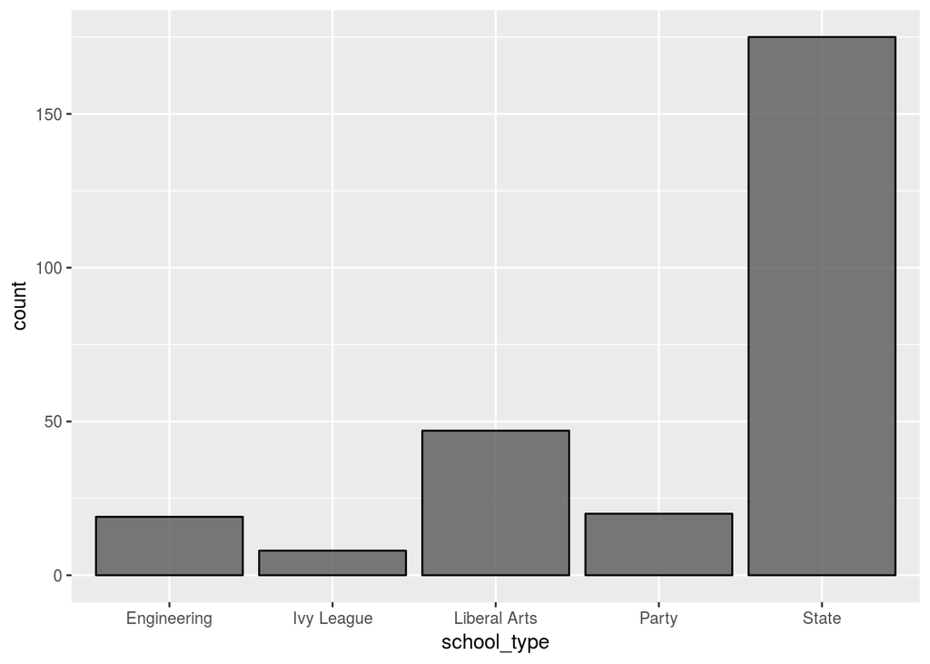

```r
ggplot(df_col, aes(school_type)) +
  geom_bar(color = 'black', alpha = 0.8)
```

most of the schools in the data set are state schools. As seen in the preliminary overview, some colleges have multiple types…

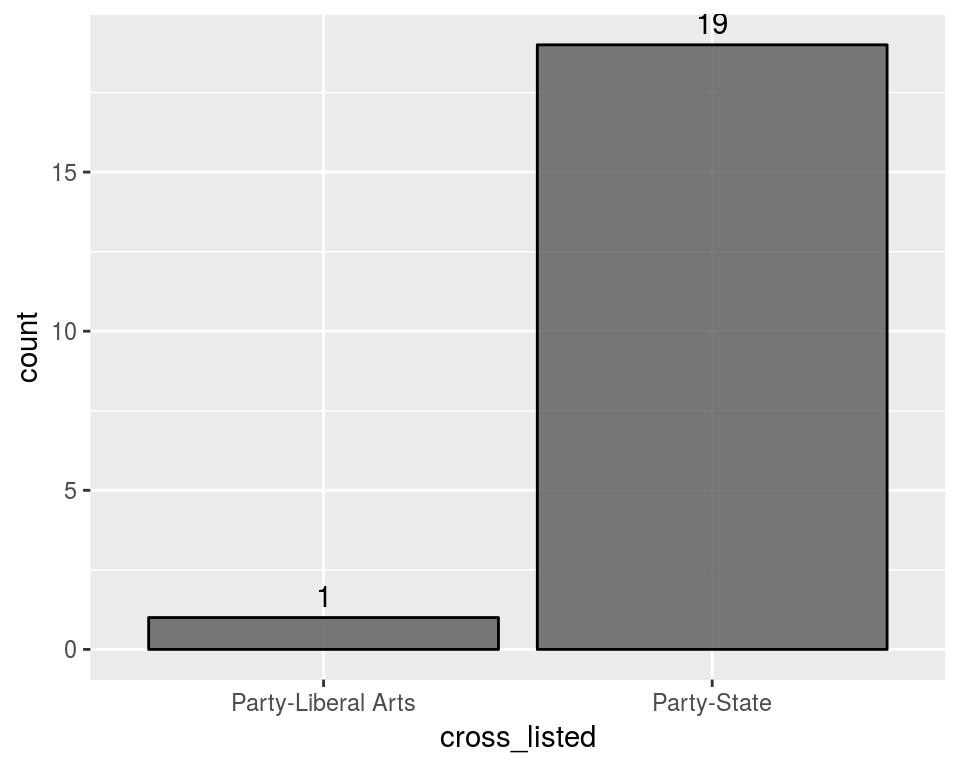

```r
# colleges that appear as more than 1 type
df_col_mult_types <- df_col %>%
  group_by(school_name) %>%
  mutate(num_types = n()) %>%
  filter(num_types > 1) %>%
  summarise(cross_listed = paste(school_type, collapse = '-')) %>%
  arrange(desc(school_name))

ggplot(df_col_mult_types, aes(cross_listed)) +
  geom_bar(color = 'black', alpha = 0.8) +
  stat_count(aes(label = ..count..), geom = "text", vjust = -0.5)
```

Again, those that do are mostly state and party schools.

```r
# names of state schools that are also party schools
logical_party_state <- df_col_mult_types$cross_listed == 'Party-State'
names_party_state <- df_col_mult_types$school_name[logical_party_state]

names_party_state
```

```
##  [1] "West Virginia University (WVU)"
##  [2] "University of Texas (UT) - Austin"
##  [3] "University of Tennessee"
##  [4] "University of New Hampshire (UNH)"
##  [5] "University of Mississippi"
##  [6] "University of Maryland, College Park"
##  [7] "University of Iowa (UI)"
##  [8] "University of Illinois at Urbana-Champaign (UIUC)"
##  [9] "University of Georgia (UGA)"
## [10] "University of Florida (UF)"
## [11] "University of California, Santa Barbara (UCSB)"
## [12] "University of Alabama, Tuscaloosa"
## [13] "State University of New York (SUNY) at Albany"
## [14] "Pennsylvania State University (PSU)"
## [15] "Ohio University"
## [16] "Louisiana State University (LSU)"
## [17] "Indiana University (IU), Bloomington"
## [18] "Florida State University (FSU)"
## [19] "Arizona State University (ASU)"
```

The one liberal arts school that is also a party school is Randolph-Macon College.

What is the relationship between starting and mid-career salary by school type?

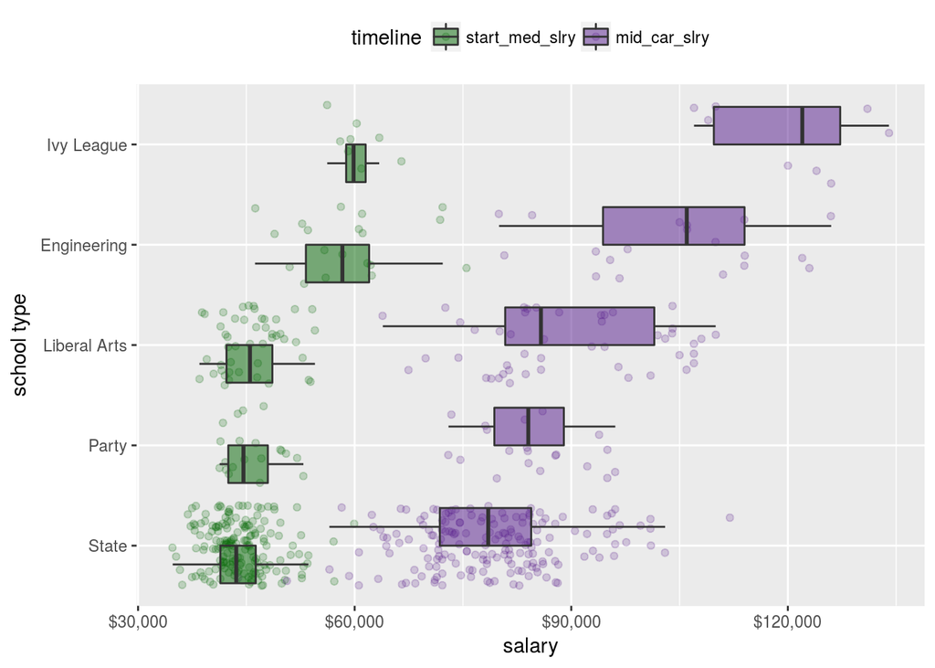

```r
# wide to long again for starting and mid-career salary
df_col_type_slry <- df_col %>%
  select(school_type, start_med_slry, mid_car_slry) %>%
  gather(timeline, salary, start_med_slry:mid_car_slry) %>%
  mutate(timeline = as_factor(timeline, fct_rev))

ggplot(df_col_type_slry, aes(reorder(school_type, salary), salary, fill = timeline)) +
  geom_jitter(aes(color = timeline), alpha = 0.2) +
  scale_color_manual(values = c('darkgreen', 'purple4')) +
  geom_boxplot(alpha = 0.5, outlier.color = NA) +
  scale_fill_manual(values = c('darkgreen', 'purple4')) +
  scale_y_continuous(labels = dollar) +
  theme(legend.position = "top") +
  xlab('school type') +
  coord_flip()
```

It’s pretty clear that both engineering and ivy league schools have higher starting and mid-career median salaries. What I’m most curious about here is the difference between state schools that are party schools, and state schools that are not party schools. Starting salaries for these two appear to be similar, although party schools seem to have a higher mid-career salary over state schools. I wonder what the differences would be focusing on the different types of state school (party and not party).

## 4.1 Should you go to a state school that is a party school?

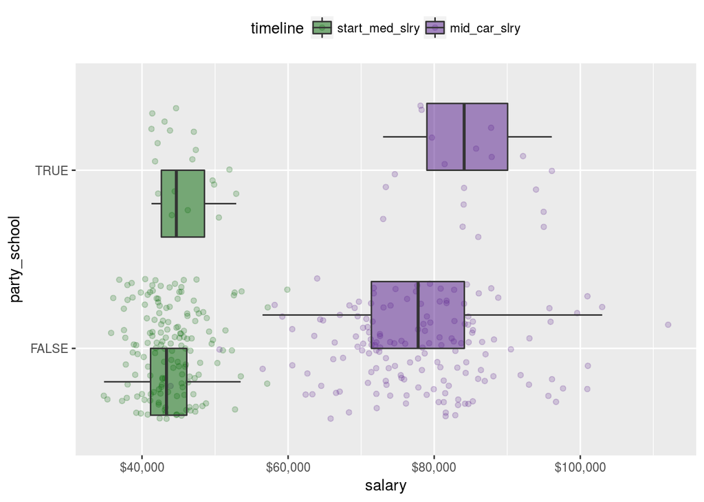

```r
# names of state schools that are not party schools
logical_state_not_party <- df_col$school_type == 'State' &
  !(df_col$school_name %in% names_party_state)  # logical vector on 'df_col'
names_state_no_party <- df_col$school_name[logical_state_not_party]
# double-check counts
stopifnot(sum(df_col$school_type == 'State') ==
            length(names_party_state) + length(names_state_no_party))

# subset college data set to include party schools and state schools separately
logical_state_and_party <- df_col$school_type == 'State' &
  !logical_state_not_party  # logical vector on 'df_col'

df_state_vs_party <- df_col %>%
  select(school_name, start_med_slry, mid_car_slry) %>%
  filter(logical_state_not_party | logical_state_and_party) %>%  # party and not party state schools
  mutate(party_school = school_name %in% names_party_state)
# wide to long
df_state_vs_party_long <- df_state_vs_party %>%
  gather(timeline, salary, start_med_slry, mid_car_slry) %>%
  mutate(timeline = as_factor(timeline, fct_rev))

# plot difference in starting and mid-career salaries
ggplot(df_state_vs_party_long, aes(party_school, salary, fill = timeline)) +
  geom_jitter(aes(color = timeline), alpha = 0.2) +
  scale_color_manual(values = c('darkgreen', 'purple4')) +
  geom_boxplot(alpha = 0.5, outlier.color = NA) +
  scale_fill_manual(values = c('darkgreen', 'purple4')) +
  scale_y_continuous(labels = dollar) +
  theme(legend.position = "top") +
  coord_flip()
```

It looks as though the mid-career salary for state schools that are party schools is higher than non-party state schools. There is much less data for state schools that are party schools and having more data would help. Let’s run a t-test to see if there is any statistical basis for this observation.

```r
df_state_vs_party_midcar_long <-
  df_state_vs_party_long[df_state_vs_party_long$timeline == 'mid_car_slry', ]

t.test(salary ~ party_school, df_state_vs_party_midcar_long)
```

```
##
##  Welch Two Sample t-test
##
## data:  salary by party_school
## t = -3.6534, df = 27.354, p-value = 0.001083
## alternative hypothesis: true difference in means is not equal to 0
## 95 percent confidence interval:
##  -10814.540  -3038.901
## sample estimates:
## mean in group FALSE  mean in group TRUE
##            77815.38            84742.11
```

It does seem that mid-career median salaries for state-party schools is higher than just state schools. Again more data would be valuable here as there aren’t a whole lot of observations for just state-party schools. Let’s see if there is any difference for starting salary.

```r
df_state_vs_party_midcar_long2 <-
  df_state_vs_party_long[df_state_vs_party_long$timeline == 'start_med_slry', ]

t.test(salary ~ party_school, df_state_vs_party_midcar_long2)
```

```
##
##  Welch Two Sample t-test
##
## data:  salary by party_school
## t = -2.1414, df = 24.274, p-value = 0.04248
## alternative hypothesis: true difference in means is not equal to 0
## 95 percent confidence interval:
##  -3859.98495   -72.26876
## sample estimates:
## mean in group FALSE  mean in group TRUE
##            43912.82            45878.95
```

I’m pretty suprised that there is some statistical significance here. Again, more data would help, but this seems to imply that if you have the chance to attend a state school, all other factors being equal, it would be better to attend a state school that is also a party school. The starting and mid-career median salaries are statistically higher for state-party schools as opposed to state non-party schools.

## 4.2 Top 20 schools by type

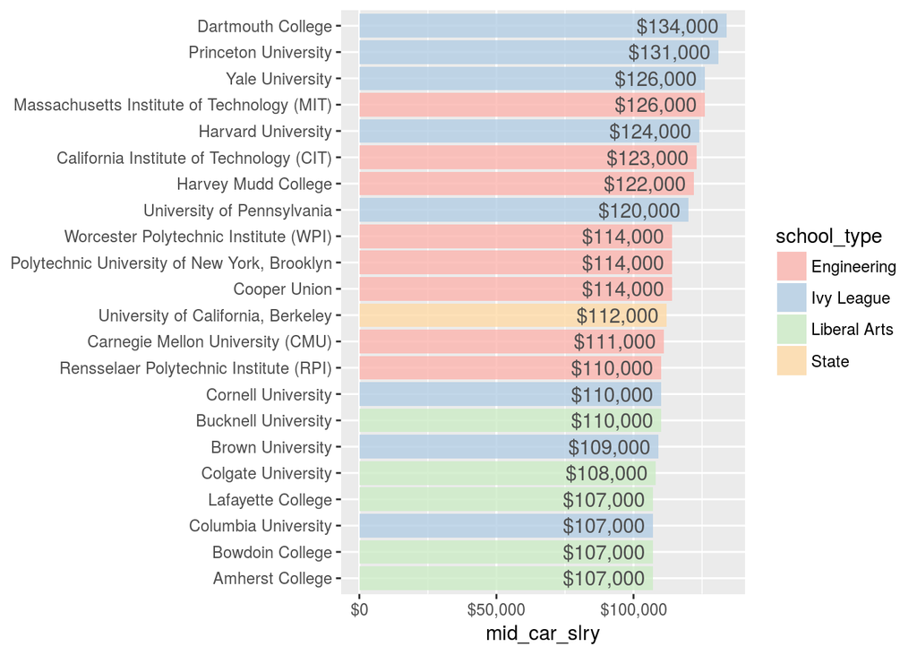

```r
library(RColorBrewer)
accent_colors_edit <- brewer.pal(n = 5, "Pastel1")[c(1:3, 5)]  # keep colors consistent for plot w/o 'party'

df_col_top20 <- df_col %>%
  select(school_name, school_type, mid_car_slry) %>%
  arrange(desc(mid_car_slry)) %>%
  top_n(20)

ggplot(df_col_top20, aes(reorder(school_name, mid_car_slry), mid_car_slry, fill = school_type)) +
  geom_col(alpha = 0.8) +
  scale_fill_manual(values = accent_colors_edit) +
  geom_text(aes(label = dollar(mid_car_slry)), hjust = 1.1, color = 'gray30') +
  scale_y_continuous(labels = dollar) +
  xlab(NULL) +
  coord_flip()
```

Ivy leagues are mostly towards the top, followed by engineering, ‘go bears!’, and liberal arts.

# 5 Salaries by region

Here is a look at the salaries by college region data set. What is the distribution across regions?

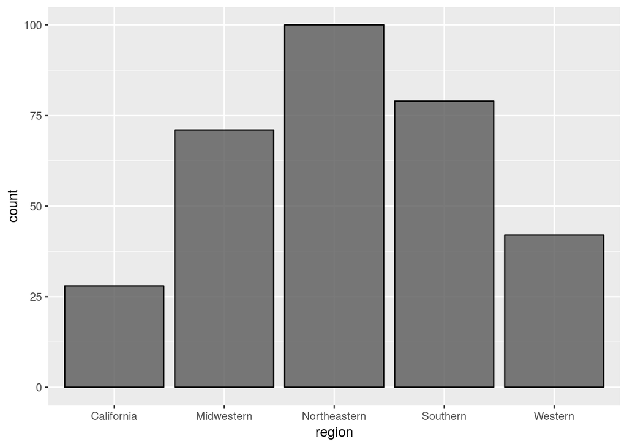

```r
ggplot(df_reg, aes(region)) +
  geom_bar(color = 'black', alpha = 0.8)
```

It’s kinda funny that California gets it’s own region. Being from this state, I do know there are a good number of Universities/Colleges here and the demand to come to California is high for both study and work.

Take a look if there is any difference in starting or mid-career salary by region.

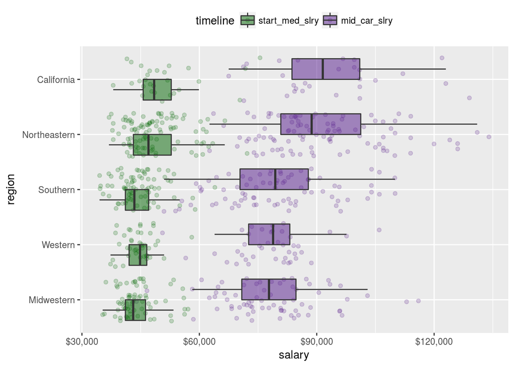

```r
# wide to long
df_reg_slry <- df_reg %>%
  select(region, start_med_slry, mid_car_slry) %>%
  gather(timeline, salary, start_med_slry:mid_car_slry) %>%
  mutate(timeline = as_factor(timeline, fct_rev))

ggplot(df_reg_slry, aes(reorder(region, salary), salary, fill = timeline)) +
  geom_jitter(aes(color = timeline), alpha = 0.2) +
  scale_color_manual(values = c('darkgreen', 'purple4')) +
  geom_boxplot(alpha = 0.5, outlier.color = NA) +
  scale_fill_manual(values = c('darkgreen', 'purple4')) +
  scale_y_continuous(labels = dollar) +
  theme(legend.position = "top") +
  xlab('region') +
  coord_flip()
```

This is interesting, both California and the Northeastern region appear to have both higher starting and mid-career salaries. Most Ivy League schools are in the Northeastern region, so this could be in part due to that.

## 5.1 Region across type

There are a few colleges for which there are both type and region data in their respective data sets. We can combine these to see if we can come up with any finer insights about salary across these 2 categories.

First, what does the distribution look like across college type and region?

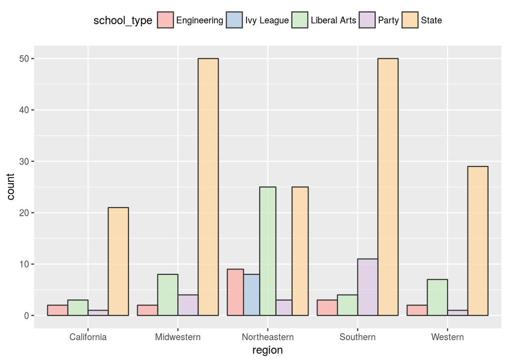

```r
# keep college names and types from the college data set
logical_keep_type_cols <- colnames(df_col) %in% c('school_name', 'school_type')
# inner join (leave any non-matched schools out)
df_reg_col <- merge(x = df_reg, y = df_col[, logical_keep_type_cols],
                    by = 'school_name')

ggplot(df_reg_col, aes(region, fill = school_type)) +
  geom_bar(position = 'dodge', alpha = 0.8, color = 'gray20') +
  scale_fill_brewer(palette = 'Pastel1') +
  theme(legend.position = "top")
```

The northeastern region seems to dominate when it comes to ivy league (all accounted for), liberal arts, and engineering schools… the most party schools seem to be in the south.

How do starting salary and mid-career median salary differ over these regions?

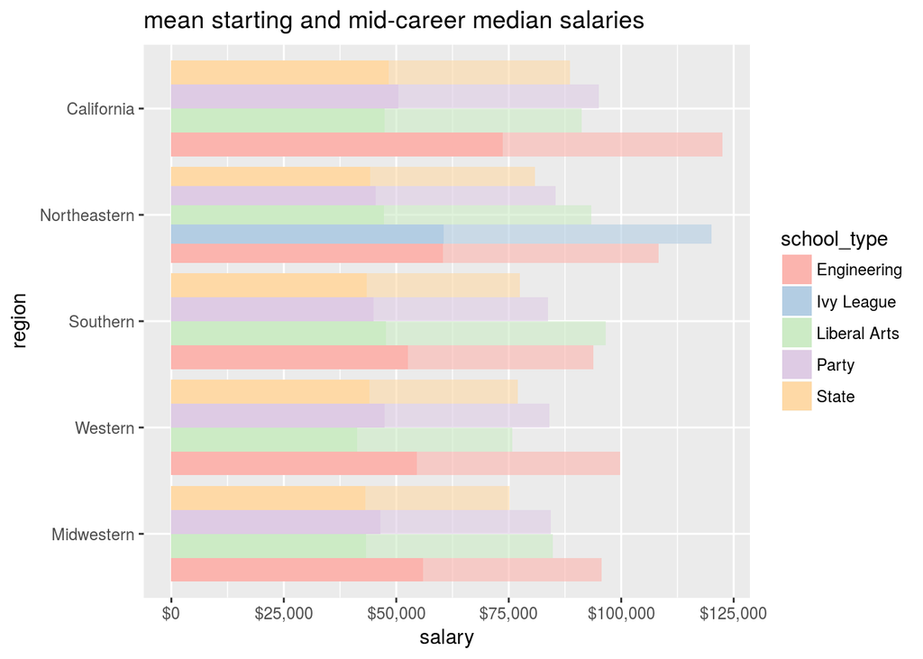

```r
# average of medians, not a great statistic
#ggplot(df_reg_col, aes(region, school_type, z = start_med_slry)) +
#  stat_summary_2d()

# bar chart better than 2d density w/ color
ggplot(df_reg_col, aes(reorder(region, start_med_slry), mid_car_slry, fill = school_type)) +
  stat_summary(geom = 'col', position = 'dodge', alpha = 0.6) +
  stat_summary(aes(region, start_med_slry, fill = school_type),
               geom = 'col', position = 'dodge') +
  scale_fill_brewer(palette = 'Pastel1') +
  scale_y_continuous(labels = dollar) +
  xlab('region') +
  ylab('salary') +
  ggtitle('mean starting and mid-career median salaries') +
  coord_flip()
```

Superimposed on the median starting career salaries with a lighter shade, is the mean mid-career median salary. The better median starting salaries across almost all regions is dominated by engineering schools. In the northeast, engineering and ivy league starting salaries are pretty even. But mid-career the value of an ivy league education is superior. Interestingly, in the south, mid-career salaries tend to be higher for liberal arts schools. In California and the rest of the west, if you can’t get into an engineering school, it appears better to attend a party school than a state school for mid-career salary potential.

## 5.2 Top 20 schools by region

Because the regions data set had the most observations, I want to do another top 20 list and see if any schools pop-up that weren’t on the types data set.

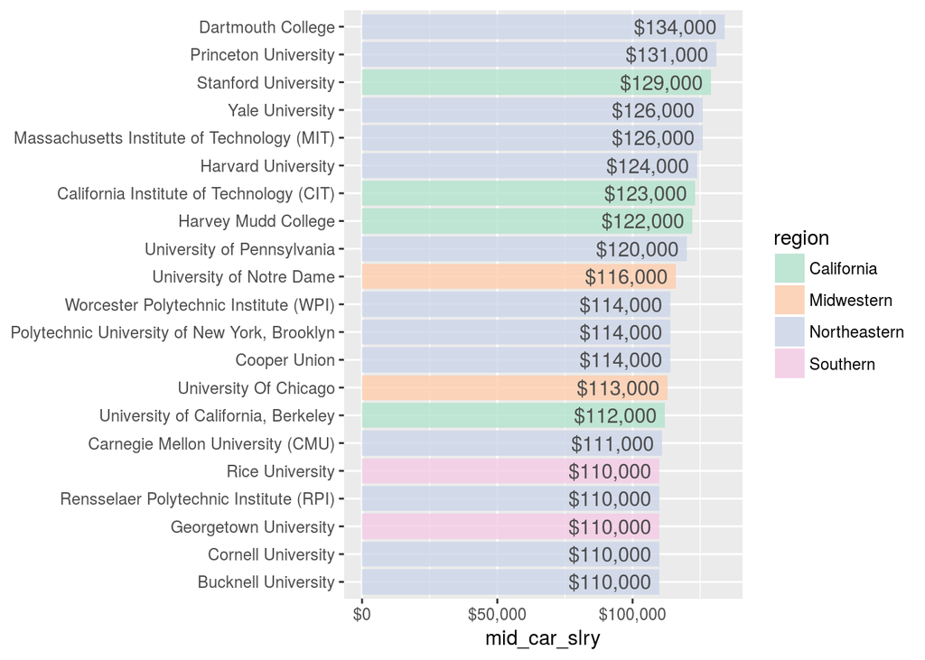

```r
df_reg_top20 <- df_reg %>%
  select(school_name, region, mid_car_slry) %>%
  arrange(desc(mid_car_slry)) %>%
  top_n(20)

ggplot(df_reg_top20, aes(reorder(school_name, mid_car_slry), mid_car_slry, fill = region)) +
  geom_col(alpha = 0.8) +
  geom_text(aes(label = dollar(mid_car_slry)), hjust = 1.1, color = 'gray30') +
  scale_fill_brewer(palette = 'Pastel2') +
  scale_y_continuous(labels = dollar) +
  xlab(NULL) +
  coord_flip()
```

A few important colleges pop-up here like Stanford. I can see why this didn’t have a ‘type’ as it’s more like a ‘west coast ivy’. Rice University is also a little difficult to pin down as it’s often referred to as the ‘Harvard of the south’. Here’s a full list of new appearances in the top 20 mid-career salary by region.

```r
df_reg_top20$school_name[!df_reg_top20$school_name %in% df_col_top20$school_name]
```

```
## [1] "Stanford University"      "University of Notre Dame"
## [3] "University Of Chicago"    "Rice University"
## [5] "Georgetown University"
```

# 6 Reflections

So what kind of general statements can we make about post-college salaries?

- by major
  - if you want the highest starting salary, look into engineering or becoming a physician’s assistant
  - if you want to see the most percent growth in salary from start to mid-career look into philosophy and math
  - if highest mid-career salary is what you’re after, consider engineering
- by college type
  - most colleges are state schools
  - ivy league and engineering schools have the best long term mid-career salary potential (followed by liberal arts)
  - if you are going to a state school, consider one that is also a party school
- by region
  - try to go to school in California or the northeast
  - considering **both** college type and region, go to the northeast for an ivy league school.
  - again considering both type and region, go to California for an engineering, party, or state school
  - if you want a liberal arts school, the south seems to be slightly better than California or the northeast